# Trabajo 1 · Series de tiempo — Código del equipo: ST8ZPT

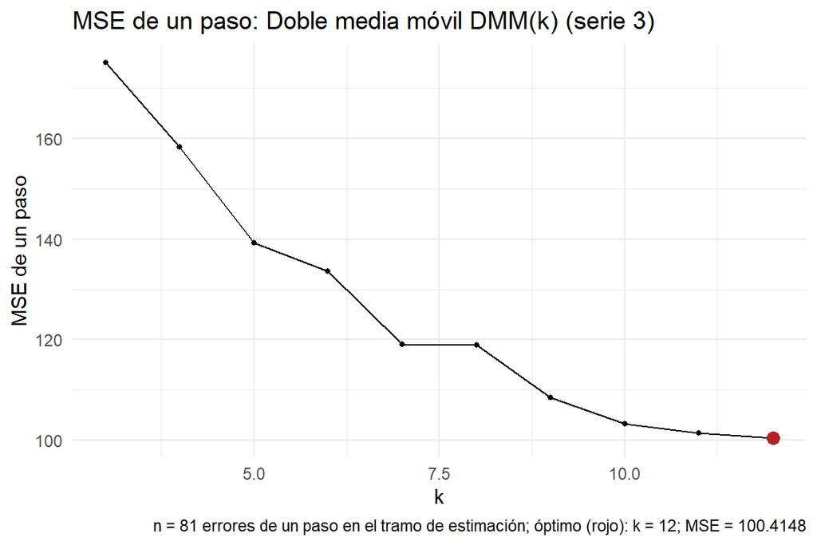

Figura 33: **?(caption)**

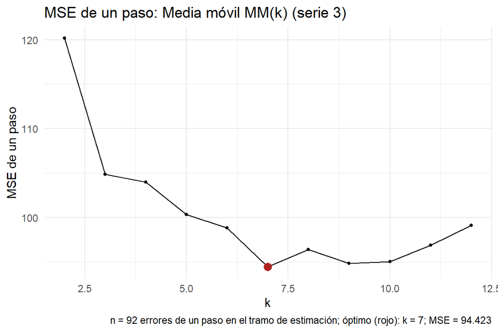

Figura 34: **?(caption)**

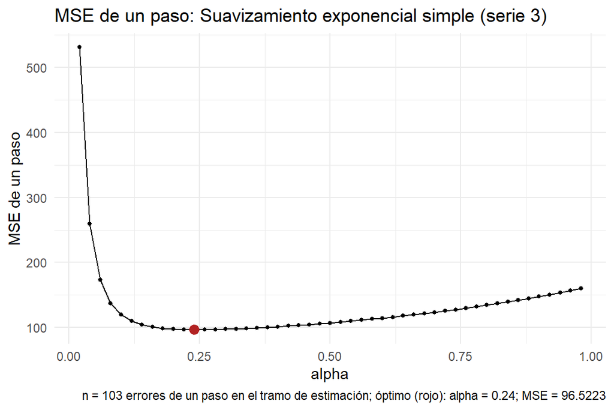

Figura 35: **?(caption)**

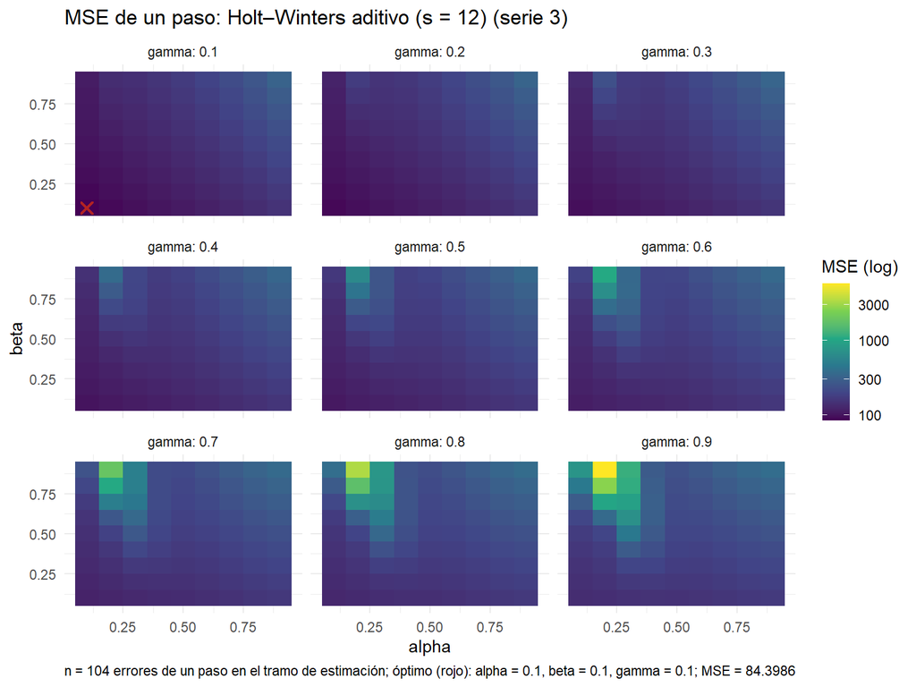

Figura 36: **?(caption)**

## 6.3 Regresiones de tendencia: coeficientes, errores estándar robustos y residuos

Para cada tendencia ajustada por mínimos cuadrados (con o sin ficticias) sobre toda la serie se reporta el coeficiente, el error estándar ordinario y el error estándar robusto a autocorrelación con núcleo de Bartlett (HAC, con $L = \lfloor 4(n/100)^{2/9}\rfloor$ rezagos), y la prueba $t$ **con el error robusto**. Cada fila de las tablas es una prueba de hipótesis con los seis elementos: (1) $H_0:\beta_j = 0$ contra $H_1:\beta_j \neq 0$; (2) el estadístico es $t = \hat\beta_j / EE_{HAC}(\hat\beta_j)$, que bajo $H_0$ se aproxima por una $t$ de Student con $n-k$ grados de libertad; (3) la región de rechazo al 5 % es $|t| > t_{0{,}975,\,n-k}$, cuyo valor crítico aparece en la tabla; (4) el valor observado de $t$ y su valor $p$ son las columnas respectivas; (5) la decisión se lee de la columna final; (6) la lectura se hace en el texto de cada serie. La serie exponencial se ajusta en logaritmos.

### 6.3.1 Serie 1

**?(caption)**

**Tendencia lineal** (n = 180, k = 2, $L$ = 4)

| Término | Estimación | EE ordinario | EE HAC | t (HAC) | Valor crítico | Valor p | Decisión |
| --- | --- | --- | --- | --- | --- | --- | --- |
| Intercepto | 42,4715 | 2,1466 | 1,4147 | 30,0208 | 1,9734 | < 0,0001 | se rechaza H0 |
| t | 0,2202 | 0,0206 | 0,0187 | 11,7792 | 1,9734 | < 0,0001 | se rechaza H0 |

**Tendencia + ficticias (s = 12)** (n = 180, k = 13, $L$ = 4)

| Término | Estimación | EE ordinario | EE HAC | t (HAC) | Valor crítico | Valor p | Decisión |
| --- | --- | --- | --- | --- | --- | --- | --- |
| Intercepto | 43,2409 | 0,7149 | 1,0213 | 42,3410 | 1,9743 | < 0,0001 | se rechaza H0 |
| t | 0,2117 | 0,0069 | 0,0132 | 16,0655 | 1,9743 | < 0,0001 | se rechaza H0 |
| D2-D1 | -12,2376 | 1,1790 | 0,9526 | -12,8460 | 1,9743 | < 0,0001 | se rechaza H0 |
| D3-D1 | -4,0526 | 1,1788 | 0,5905 | -6,8635 | 1,9743 | < 0,0001 | se rechaza H0 |
| D4-D1 | -10,5943 | 1,1787 | 0,7685 | -13,7856 | 1,9743 | < 0,0001 | se rechaza H0 |
| D5-D1 | 7,8806 | 1,1786 | 1,0106 | 7,7978 | 1,9743 | < 0,0001 | se rechaza H0 |
| D6-D1 | 13,9576 | 1,1786 | 1,1175 | 12,4896 | 1,9743 | < 0,0001 | se rechaza H0 |
| D7-D1 | -0,6801 | 1,1786 | 0,6351 | -1,0709 | 1,9743 | 0,286 | no se rechaza H0 |
| D8-D1 | -15,2258 | 1,1786 | 0,9361 | -16,2652 | 1,9743 | < 0,0001 | se rechaza H0 |
| D9-D1 | -14,4709 | 1,1787 | 0,9131 | -15,8475 | 1,9743 | < 0,0001 | se rechaza H0 |
| D10-D1 | -5,2793 | 1,1788 | 0,6475 | -8,1532 | 1,9743 | < 0,0001 | se rechaza H0 |
| D11-D1 | 24,1177 | 1,1790 | 1,8147 | 13,2899 | 1,9743 | < 0,0001 | se rechaza H0 |
| D12-D1 | 23,5460 | 1,1792 | 1,5599 | 15,0945 | 1,9743 | < 0,0001 | se rechaza H0 |

**?(caption)**

| Regresión | Q (Ljung–Box) | p (LB) | JB | p (JB) | DW | 2(1 − r1) |
| --- | --- | --- | --- | --- | --- | --- |
| Tendencia lineal | 1005,594 | < 0,0001 | 18,539 | < 0,0001 | 1,167 | 1,220 |
| Tendencia + ficticias (s = 12) | 434,565 | < 0,0001 | 204,964 | < 0,0001 | 0,605 | 0,731 |

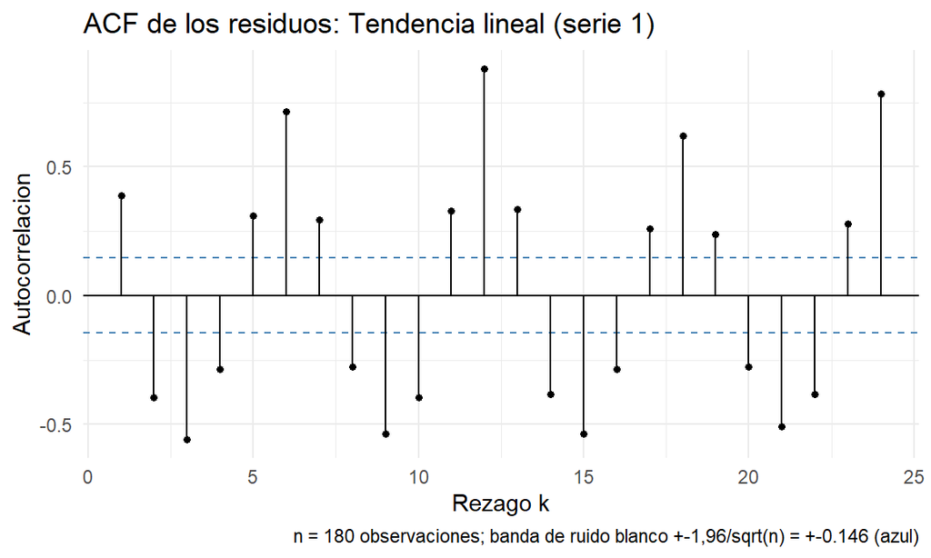

Figura 37: **?(caption)**

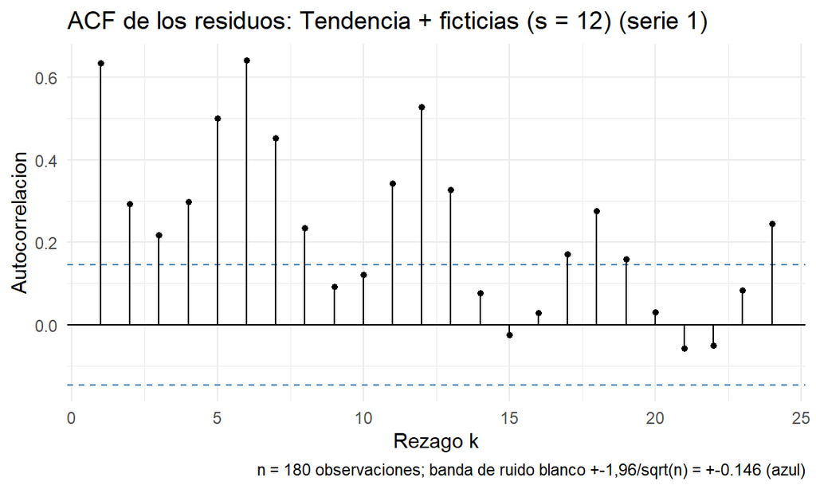

Figura 38: **?(caption)**

En la tendencia lineal la pendiente es 0,220 mil turistas por mes; el error estándar ordinario es 0,0206 y el HAC 0,0187, pero la inferencia importa poco aquí porque los residuos de esa recta no son ruido blanco: Ljung–Box rechaza con $p$ < 0,0001 y $DW =$ 1,167, cercano a $2(1-r_1) =$ 1,220: autocorrelación positiva fuerte, porque la recta deja entero el perfil estacional en los residuos. La tendencia con ficticias de suma cero estima una pendiente de 0,212 mil turistas por mes (EE HAC 0,0132, $t =$ 16,1), y 10 de los 11 contrastes de ficticias rechazan $H_0$ (el efecto de los siguientes meses no se distingue del de enero: jul). Aun así los residuos conservan estructura: Ljung–Box rechaza ($p$ < 0,0001), $DW =$ 0,605 frente a $2(1-r_1) =$ 0,731, y Jarque–Bera rechaza normalidad ($p$ < 0,0001). La razón es que la amplitud estacional crece con el nivel, algo que unos índices fijos de suma cero no pueden seguir (sección 3b).

Con los seis elementos, la prueba de Ljung–Box sobre los residuos de la tendencia con ficticias de la serie 1:

**Prueba de Ljung-Box sobre los residuos de la tendencia + ficticias (s = 12) (m = 24)**

1. **Hipótesis.** $H_0$: $\rho_1 = \dots = \rho_m = 0$ (no hay autocorrelación hasta el rezago $m$). $H_1$: algún $\rho_k \neq 0$ con $k \leq m$.
2. **Estadístico.** $Q = n(n+2)\sum_{k=1}^{m} \frac{r_k^2}{n-k}$. Bajo $H_0$: $\chi^2$ con 24 grados de libertad.
3. **Región de rechazo al 5 %.** $Q > 36,42$.
4. **Valor observado.** $Q = 434,6$; valor p = < 0,0001.
5. **Decisión.** Se rechaza H0.
6. **Lectura.** Hay autocorrelación en los residuos de la tendencia + ficticias (s = 12) hasta el rezago 24: no se comporta como ruido blanco.

### 6.3.2 Serie 2

**?(caption)**

**Tendencia lineal** (n = 180, k = 2, $L$ = 4)

| Término | Estimación | EE ordinario | EE HAC | t (HAC) | Valor crítico | Valor p | Decisión |
| --- | --- | --- | --- | --- | --- | --- | --- |
| Intercepto | 216,5783 | 2,5436 | 5,6610 | 38,2580 | 1,9734 | < 0,0001 | se rechaza H0 |
| t | 0,6386 | 0,0244 | 0,0512 | 12,4783 | 1,9734 | < 0,0001 | se rechaza H0 |

**Tendencia cuadrática** (n = 180, k = 3, $L$ = 4)

| Término | Estimación | EE ordinario | EE HAC | t (HAC) | Valor crítico | Valor p | Decisión |
| --- | --- | --- | --- | --- | --- | --- | --- |
| Intercepto | 187,2779 | 2,4920 | 3,1323 | 59,7889 | 1,9735 | < 0,0001 | se rechaza H0 |
| t | 1,6046 | 0,0636 | 0,1096 | 14,6416 | 1,9735 | < 0,0001 | se rechaza H0 |
| t2 | -0,0053 | 0,0003 | 0,0006 | -8,6731 | 1,9735 | < 0,0001 | se rechaza H0 |

**Tendencia exponencial** (n = 180, k = 2, $L$ = 4)

| Término | Estimación | EE ordinario | EE HAC | t (HAC) | Valor crítico | Valor p | Decisión |
| --- | --- | --- | --- | --- | --- | --- | --- |
| Intercepto | 5,3812 | 0,0104 | 0,0251 | 214,4228 | 1,9734 | < 0,0001 | se rechaza H0 |
| t | 0,0025 | 0,0001 | 0,0002 | 11,0773 | 1,9734 | < 0,0001 | se rechaza H0 |

**?(caption)**

| Regresión | Q (Ljung–Box) | p (LB) | JB | p (JB) | DW | 2(1 − r1) |
| --- | --- | --- | --- | --- | --- | --- |
| Tendencia lineal | 1238,170 | < 0,0001 | 4,782 | 0,092 | 0,172 | 0,187 |
| Tendencia cuadrática | 603,269 | < 0,0001 | 0,265 | 0,876 | 0,410 | 0,421 |
| Tendencia exponencial | 1323,309 | < 0,0001 | 1,188 | 0,552 | 0,149 | 0,166 |

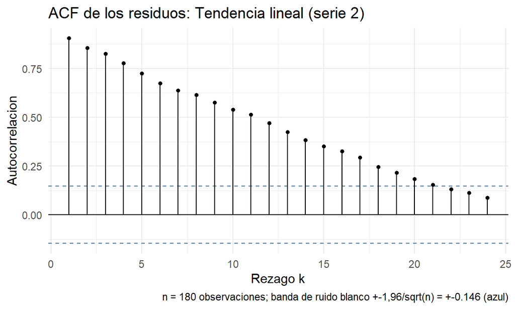

Figura 39: **?(caption)**

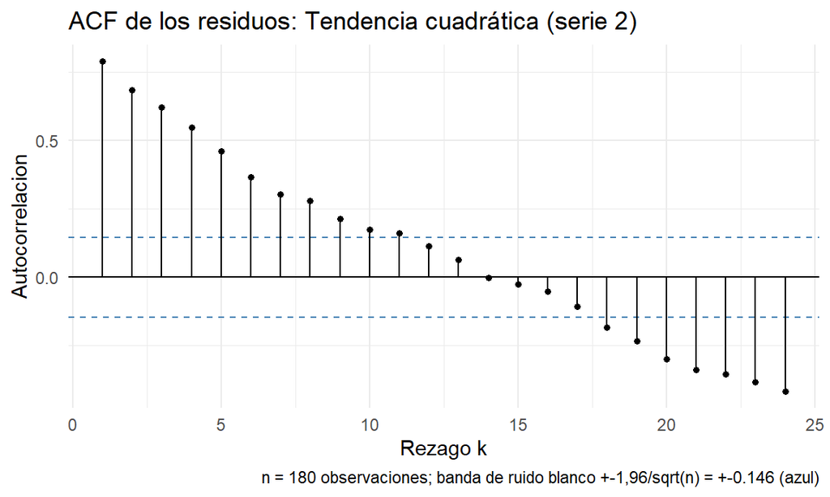

Figura 40: **?(caption)**

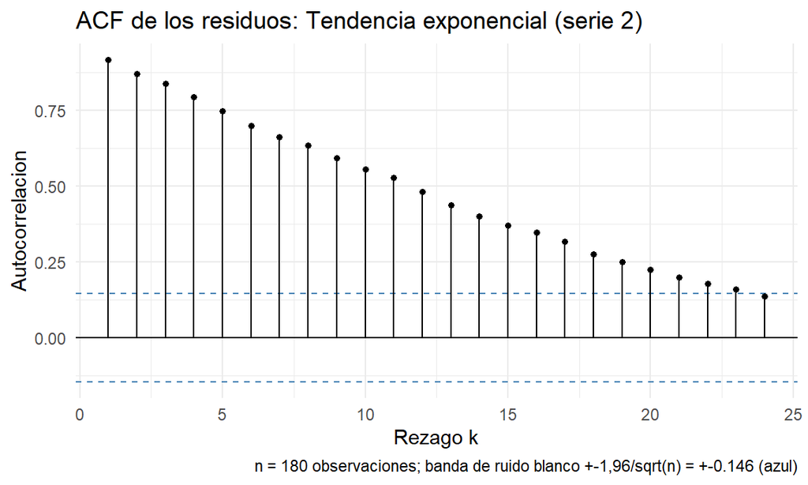

Figura 41: **?(caption)**

El error estándar HAC de la pendiente de la tendencia lineal es 0,0512 frente a 0,0244 del ordinario, 2,1 veces mayor: la autocorrelación positiva de los residuos hace que el ordinario subestime la incertidumbre. En la cuadrática el término $t^2$ es significativo con el error robusto ($t =$ -8,67, $p$ < 0,0001) y negativo: la serie sube y se aplana. Sin embargo, en las tres regresiones de esta serie los residuos conservan autocorrelación muy fuerte (Ljung–Box rechaza con $p$ < 0,0001, < 0,0001 y < 0,0001; $DW$ de 0,17, 0,41 y 0,15, cercanos a $2(1-r_1)$): una tendencia determinista no describe esta serie, y la significancia de sus coeficientes no debe leerse como evidencia de que el modelo es correcto.

Con los seis elementos, la prueba de Ljung–Box sobre los residuos de la cuadrática (la mejor de las tres en h = 9):

**Prueba de Ljung-Box sobre los residuos de la tendencia cuadrática (m = 24)**

1. **Hipótesis.** $H_0$: $\rho_1 = \dots = \rho_m = 0$ (no hay autocorrelación hasta el rezago $m$). $H_1$: algún $\rho_k \neq 0$ con $k \leq m$.
2. **Estadístico.** $Q = n(n+2)\sum_{k=1}^{m} \frac{r_k^2}{n-k}$. Bajo $H_0$: $\chi^2$ con 24 grados de libertad.
3. **Región de rechazo al 5 %.** $Q > 36,42$.
4. **Valor observado.** $Q = 603,3$; valor p = < 0,0001.
5. **Decisión.** Se rechaza H0.
6. **Lectura.** Hay autocorrelación en los residuos de la tendencia cuadrática hasta el rezago 24: no se comporta como ruido blanco.

### 6.3.3 Serie 3

**?(caption)**

**Tendencia lineal** (n = 130, k = 2, $L$ = 4)

| Término | Estimación | EE ordinario | EE HAC | t (HAC) | Valor crítico | Valor p | Decisión |
| --- | --- | --- | --- | --- | --- | --- | --- |
| Intercepto | 118,4877 | 1,6094 | 1,4306 | 82,8253 | 1,9787 | < 0,0001 | se rechaza H0 |
| t | 0,6232 | 0,0213 | 0,0211 | 29,5640 | 1,9787 | < 0,0001 | se rechaza H0 |

**Tendencia cuadrática** (n = 130, k = 3, $L$ = 4)

| Término | Estimación | EE ordinario | EE HAC | t (HAC) | Valor crítico | Valor p | Decisión |
| --- | --- | --- | --- | --- | --- | --- | --- |
| Intercepto | 119,4966 | 2,4442 | 2,1453 | 55,7018 | 1,9788 | < 0,0001 | se rechaza H0 |
| t | 0,5773 | 0,0861 | 0,0822 | 7,0238 | 1,9788 | < 0,0001 | se rechaza H0 |
| t2 | 0,0004 | 0,0006 | 0,0006 | 0,5445 | 1,9788 | 0,587 | no se rechaza H0 |

**Tendencia exponencial** (n = 130, k = 2, $L$ = 4)

| Término | Estimación | EE ordinario | EE HAC | t (HAC) | Valor crítico | Valor p | Decisión |
| --- | --- | --- | --- | --- | --- | --- | --- |
| Intercepto | 4,7993 | 0,0101 | 0,0095 | 504,2381 | 1,9787 | < 0,0001 | se rechaza H0 |
| t | 0,0040 | 0,0001 | 0,0001 | 31,0722 | 1,9787 | < 0,0001 | se rechaza H0 |

**?(caption)**

| Regresión | Q (Ljung–Box) | p (LB) | JB | p (JB) | DW | 2(1 − r1) |
| --- | --- | --- | --- | --- | --- | --- |
| Tendencia lineal | 30,310 | 0,175 | 0,579 | 0,749 | 2,066 | 2,071 |
| Tendencia cuadrática | 30,390 | 0,172 | 0,459 | 0,795 | 2,071 | 2,076 |
| Tendencia exponencial | 26,682 | 0,319 | 0,055 | 0,973 | 2,037 | 2,048 |

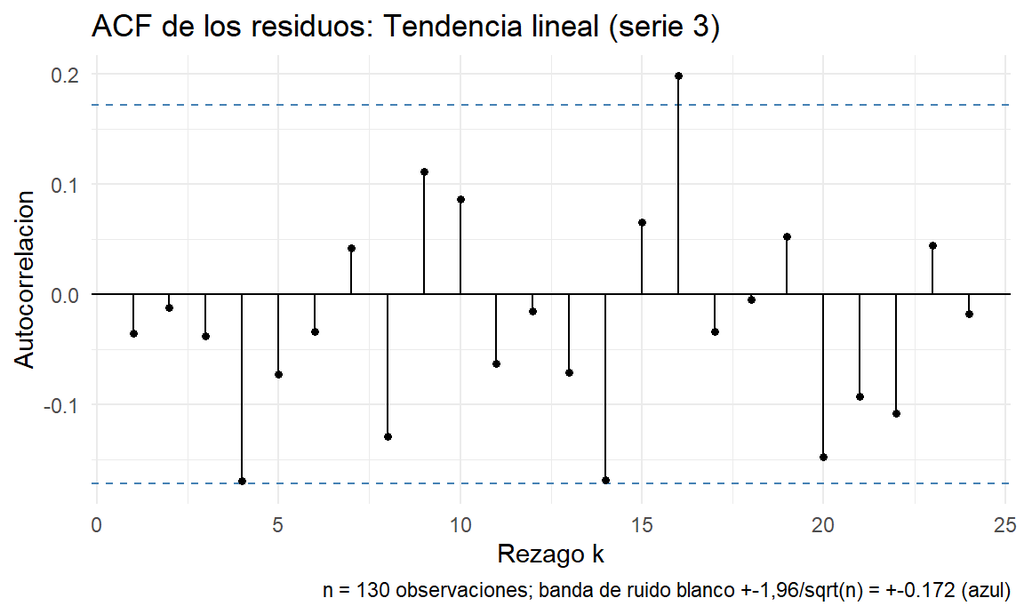

Figura 42: **?(caption)**

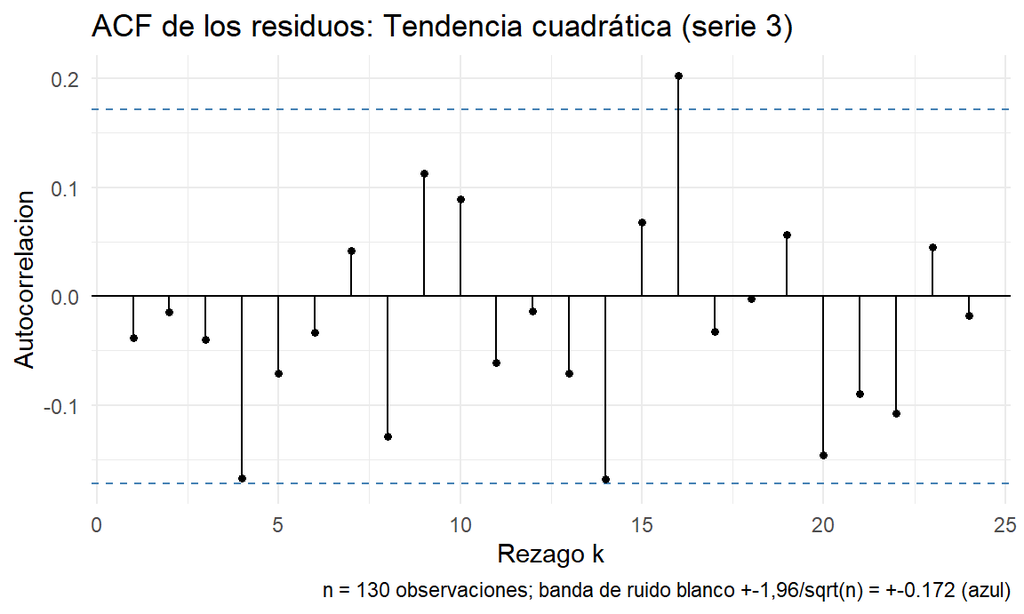

Figura 43: **?(caption)**

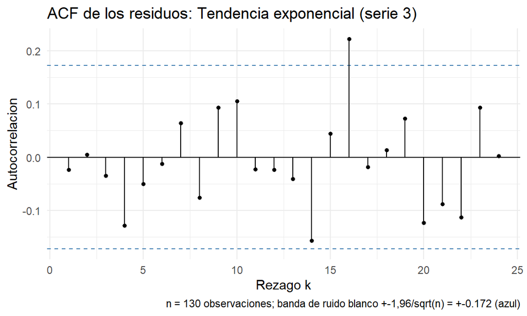

Figura 44: **?(caption)**

La recta de la serie 3 tiene pendiente 0,623 estudiantes por mes (EE ordinario 0,0213, EE HAC 0,0211; $t =$ 29,6) y un nivel de 118,5 estudiantes en $t=0$. Aquí los dos errores estándar casi coinciden, como corresponde a unos residuos sin autocorrelación: Ljung–Box no rechaza ($p =$ 0,175), $DW =$ 2,066 frente a $2(1-r_1) =$ 2,071, y Jarque–Bera no rechaza normalidad ($p =$ 0,749). En la cuadrática el término $t^2$ no es significativo con el error robusto ($t =$ 0,54, $p =$ 0,587), de modo que la curvatura no se justifica y la recta basta. Es la única serie donde la tendencia determinista supera la validación de residuos.

Con los seis elementos, la prueba de Ljung–Box (con $m = 24$ y referida a $\chi^2_m$) y la de Jarque–Bera sobre los residuos de la recta:

**Prueba de Ljung-Box sobre los residuos de la tendencia lineal (m = 24)**

1. **Hipótesis.** $H_0$: $\rho_1 = \dots = \rho_m = 0$ (no hay autocorrelación hasta el rezago $m$). $H_1$: algún $\rho_k \neq 0$ con $k \leq m$.
2. **Estadístico.** $Q = n(n+2)\sum_{k=1}^{m} \frac{r_k^2}{n-k}$. Bajo $H_0$: $\chi^2$ con 24 grados de libertad.
3. **Región de rechazo al 5 %.** $Q > 36,42$.
4. **Valor observado.** $Q = 30,31$; valor p = 0,175.
5. **Decisión.** No se rechaza H0.
6. **Lectura.** No hay evidencia de autocorrelación en los residuos de la tendencia lineal hasta el rezago 24: es compatible con ruido blanco.

**Prueba de Jarque-Bera sobre los residuos de la tendencia lineal**

1. **Hipótesis.** $H_0$: asimetría $= 0$ y curtosis $= 3$ (normalidad). $H_1$: asimetría $\neq 0$ o curtosis $\neq 3$.
2. **Estadístico.** $JB = \frac{n}{6}\left(S^2 + \frac{(K-3)^2}{4}\right)$. Bajo $H_0$: $\chi^2$ con 2 grados de libertad.
3. **Región de rechazo al 5 %.** $JB > 5,991$.
4. **Valor observado.** $JB = 0,5785$; valor p = 0,749.
5. **Decisión.** No se rechaza H0.
6. **Lectura.** No hay evidencia contra la normalidad de los residuos de la tendencia lineal ($S =$ 0,1423, $K =$ 3,161).

## 6.4 Origen móvil: tablas por horizonte

Para cada serie, todos los métodos usan **los mismos orígenes**: $o = n_0,\dots,T-1$ para $h=1$ y $o = n_0,\dots,T-H$ para $h = H$. En cada origen el método recibe únicamente $y_1,\dots,y_o$, con los parámetros fijos elegidos en el tramo de estimación. Las tablas están ordenadas de menor a mayor RMSE, el **referente** es una fila más (en negrita) y los métodos que no lo superan se quedan en la tabla. RMSE y MAD están en la unidad de la serie; MAPE en porcentaje. “Razón” es el RMSE del método dividido por el del referente: menor que 1 significa que lo supera.

### 6.4.1 Serie 1 (referente: ingenuo estacional, $s = 12$)

El perfil de la serie 1 se repite cada 12 meses (sección 3b), así que el referente honesto es el ingenuo estacional, que pronostica cada mes con el mismo mes del año anterior; el ingenuo simple ignoraría la estacionalidad y sería un referente demasiado fácil de superar.

**?(caption)**

**Horizonte h = 1** (36 orígenes)

| Método | Papel | Parámetros | n | RMSE | MAD | MAPE | Razón | ¿Supera al referente? |
| --- | --- | --- | --- | --- | --- | --- | --- | --- |
| Holt–Winters multiplicativo (s = 12) | sostenido | s = 12, α = 0,5, β = 0,1, γ = 0,1 | 36 | 2,958 | 2,343 | 2,837 | 0,437 | sí |
| Holt–Winters aditivo (s = 12) | sostenido | s = 12, α = 0,2, β = 0,1, γ = 0,8 | 36 | 3,336 | 2,648 | 3,143 | 0,493 | sí |
| **Ingenuo estacional (s = 12)** | referente | s = 12 | 36 | 6,771 | 5,838 | 6,954 | 1,000 | — |
| Tendencia + ficticias (s = 12) | sostenido | s = 12 | 36 | 9,233 | 6,430 | 6,714 | 1,364 | no |
| Holt | contraste | α = 0,05, β = 0,05 | 36 | 18,922 | 15,176 | 17,886 | 2,795 | no |
| Tendencia lineal | contraste | - | 36 | 19,723 | 14,847 | 16,837 | 2,913 | no |
| Suavizamiento exponencial simple | contraste | α = 0,08 | 36 | 19,786 | 14,952 | 17,002 | 2,922 | no |
| Media simple | contraste | - | 36 | 28,616 | 21,190 | 22,418 | 4,227 | no |

**?(caption)**

**Horizonte h = 12** (25 orígenes)

| Método | Papel | Parámetros | n | RMSE | MAD | MAPE | Razón | ¿Supera al referente? |
| --- | --- | --- | --- | --- | --- | --- | --- | --- |
| Holt–Winters multiplicativo (s = 12) | sostenido | s = 12, α = 0,5, β = 0,1, γ = 0,1 | 25 | 4,193 | 3,462 | 4,200 | 0,541 | sí |
| Holt–Winters aditivo (s = 12) | sostenido | s = 12, α = 0,2, β = 0,1, γ = 0,8 | 25 | 4,536 | 3,691 | 4,215 | 0,585 | sí |
| **Ingenuo estacional (s = 12)** | referente | s = 12 | 25 | 7,756 | 7,069 | 8,237 | 1,000 | — |
| Tendencia + ficticias (s = 12) | sostenido | s = 12 | 25 | 11,572 | 9,144 | 9,617 | 1,492 | no |
| Holt | contraste | α = 0,05, β = 0,05 | 25 | 19,759 | 14,999 | 16,084 | 2,548 | no |
| Tendencia lineal | contraste | - | 25 | 21,706 | 15,888 | 16,485 | 2,799 | no |
| Suavizamiento exponencial simple | contraste | α = 0,08 | 25 | 22,274 | 16,195 | 16,464 | 2,872 | no |
| Media simple | contraste | - | 25 | 32,715 | 25,952 | 26,997 | 4,218 | no |

En $h = 1$, Holt–Winters multiplicativo (s = 12, α = 0,5, β = 0,1, γ = 0,1) tiene un RMSE de 2,958 miles de turistas frente a 6,771 del referente (razón 0,44): reduce el error 56 %. Holt–Winters aditivo es el segundo (3,336; razón 0,49). La tendencia con ficticias de suma cero **no supera al referente** (RMSE 9,233, razón 1,36): impone índices fijos y una amplitud constante en una serie cuya amplitud crece con el nivel. Los contrastes que ignoran la estacionalidad (Holt, tendencia lineal, SES y media) quedan con razones de 2,8 a 4,2, como era de esperar. En $h = 12$ el orden es el mismo, con RMSE de 4,193 para el ganador y 7,756 para el referente (razón 0,54): el error crece con el horizonte, pero la ventaja sobre el referente se mantiene.

### 6.4.2 Serie 2 (referente: ingenuo)

La serie 2 no tiene estacionalidad semanal (sección 3b), de modo que el referente es el ingenuo simple, el último dato observado.

**?(caption)**

**Horizonte h = 1** (36 orígenes)

| Método | Papel | Parámetros | n | RMSE | MAD | MAPE | Razón | ¿Supera al referente? |
| --- | --- | --- | --- | --- | --- | --- | --- | --- |
| Suavizamiento exponencial simple | sostenido | α = 0,72 | 36 | 6,243 | 5,320 | 1,727 | 0,962 | sí |
| Holt | sostenido | α = 0,7, β = 0,05 | 36 | 6,416 | 5,515 | 1,791 | 0,988 | sí |
| **Ingenuo** | referente | - | 36 | 6,491 | 5,417 | 1,759 | 1,000 | — |
| Doble media móvil DMM(k) | sostenido | k = 4 | 36 | 6,711 | 5,597 | 1,824 | 1,034 | no |
| Holt–Winters aditivo (s = 7) | contraste | s = 7, α = 0,7, β = 0,1, γ = 0,1 | 36 | 6,725 | 5,798 | 1,882 | 1,036 | no |
| Media móvil MM(k) | contraste | k = 2 | 36 | 6,742 | 5,722 | 1,857 | 1,039 | no |
| Tendencia cuadrática | sostenido | - | 36 | 8,018 | 6,393 | 2,074 | 1,235 | no |
| Ingenuo estacional (s = 7) | contraste | s = 7 | 36 | 12,391 | 9,750 | 3,178 | 1,909 | no |
| Tendencia lineal | sostenido | - | 36 | 24,483 | 23,315 | 7,669 | 3,772 | no |
| Tendencia exponencial | sostenido | - | 36 | 32,179 | 31,291 | 10,274 | 4,957 | no |
| Media simple | contraste | - | 36 | 36,667 | 35,886 | 11,663 | 5,648 | no |

**?(caption)**

**Horizonte h = 9** (28 orígenes)

| Método | Papel | Parámetros | n | RMSE | MAD | MAPE | Razón | ¿Supera al referente? |
| --- | --- | --- | --- | --- | --- | --- | --- | --- |
| Tendencia cuadrática | sostenido | - | 28 | 8,308 | 6,703 | 2,182 | 0,688 | sí |
| Ingenuo estacional (s = 7) | contraste | s = 7 | 28 | 8,755 | 6,429 | 2,112 | 0,725 | sí |
| Suavizamiento exponencial simple | sostenido | α = 0,72 | 28 | 11,438 | 8,934 | 2,922 | 0,948 | sí |
| Media móvil MM(k) | contraste | k = 2 | 28 | 11,458 | 8,839 | 2,894 | 0,949 | sí |
| **Ingenuo** | referente | - | 28 | 12,068 | 9,500 | 3,104 | 1,000 | — |
| Holt | sostenido | α = 0,7, β = 0,05 | 28 | 14,476 | 11,266 | 3,690 | 1,200 | no |
| Holt–Winters aditivo (s = 7) | contraste | s = 7, α = 0,7, β = 0,1, γ = 0,1 | 28 | 17,271 | 13,360 | 4,374 | 1,431 | no |
| Doble media móvil DMM(k) | sostenido | k = 4 | 28 | 28,585 | 25,275 | 8,281 | 2,369 | no |
| Tendencia lineal | sostenido | - | 28 | 30,303 | 29,693 | 9,761 | 2,511 | no |
| Media simple | contraste | - | 28 | 36,350 | 35,907 | 11,717 | 3,012 | no |
| Tendencia exponencial | sostenido | - | 28 | 40,066 | 39,605 | 13,006 | 3,320 | no |

En $h = 1$ la ventaja es pequeña: SES con $\alpha =$ 0,72 tiene un RMSE de 6,243 habitaciones frente a 6,491 del referente (razón 0,962, una mejora de 3,8 %), y solo 2 de los 10 métodos distintos del referente lo superan. Con 36 orígenes, una diferencia de ese tamaño no permite afirmar que SES sea mejor que el último dato. Las tendencias deterministas lineal y exponencial y la media quedan muy por detrás (razones de 3,8 a 5,6): ignoran que el nivel ya se estabilizó. En $h = 9$ gana la tendencia cuadrática (RMSE 8,308, razón 0,69), que con un parámetro cuadrático negativo pronostica una ligera baja del nivel; pierde en $h = 1$ (razón 1,24) y gana en $h = 9$: el ganador depende del horizonte.

Un resultado hay que decirlo sin esconderlo: en $h = 9$ el ingenuo estacional de período 7, que es un **contraste** cuyo supuesto la descomposición contradice, supera al referente (RMSE 8,755, razón 0,73). No es evidencia de estacionalidad semanal: con $h = 9$ ese método pronostica con el dato de hace cinco días y no con el último, y como el último dato es ruidoso ($r_1$ de $\nabla Y$ vale -0,24), es esperable que métodos que no se apoyan solo en él mejoren al referente; la media móvil MM(k = 2) y SES, que no suponen estacionalidad, también lo superan en $h = 9$ (razones 0,95 y 0,95). La evidencia de la sección 3 contra la estacionalidad semanal no cambia por este resultado.

### 6.4.3 Serie 3 (referente: ingenuo)

La serie 3 no tiene estacionalidad (sección 3b); el referente es el ingenuo simple.

**?(caption)**

**Horizonte h = 1** (26 orígenes)

| Método | Papel | Parámetros | n | RMSE | MAD | MAPE | Razón | ¿Supera al referente? |
| --- | --- | --- | --- | --- | --- | --- | --- | --- |
| Tendencia lineal | sostenido | - | 26 | 10,795 | 8,781 | 4,591 | 0,762 | sí |
| Tendencia cuadrática | sostenido | - | 26 | 11,040 | 8,912 | 4,669 | 0,779 | sí |
| Holt | sostenido | α = 0,05, β = 0,15 | 26 | 11,044 | 8,917 | 4,639 | 0,779 | sí |
| Tendencia exponencial | sostenido | - | 26 | 11,176 | 8,999 | 4,788 | 0,789 | sí |
| Doble media móvil DMM(k) | sostenido | k = 12 | 26 | 11,731 | 9,023 | 4,709 | 0,828 | sí |
| Suavizamiento exponencial simple | contraste | α = 0,24 | 26 | 11,889 | 8,829 | 4,532 | 0,839 | sí |
| Holt–Winters aditivo (s = 12) | contraste | s = 12, α = 0,1, β = 0,1, γ = 0,1 | 26 | 11,956 | 9,184 | 4,790 | 0,844 | sí |
| Media móvil MM(k) | contraste | k = 7 | 26 | 12,117 | 9,357 | 4,803 | 0,855 | sí |
| **Ingenuo** | referente | - | 26 | 14,173 | 11,038 | 5,722 | 1,000 | — |
| Ingenuo estacional (s = 12) | contraste | s = 12 | 26 | 16,036 | 13,615 | 7,079 | 1,131 | no |
| Media simple | contraste | - | 26 | 38,137 | 36,414 | 18,728 | 2,691 | no |

**?(caption)**

**Horizonte h = 6** (21 orígenes)

| Método | Papel | Parámetros | n | RMSE | MAD | MAPE | Razón | ¿Supera al referente? |
| --- | --- | --- | --- | --- | --- | --- | --- | --- |
| Doble media móvil DMM(k) | sostenido | k = 12 | 21 | 10,355 | 9,082 | 4,686 | 0,712 | sí |
| Tendencia cuadrática | sostenido | - | 21 | 10,506 | 8,602 | 4,411 | 0,722 | sí |
| Tendencia lineal | sostenido | - | 21 | 10,632 | 8,732 | 4,459 | 0,731 | sí |
| Tendencia exponencial | sostenido | - | 21 | 10,700 | 8,583 | 4,472 | 0,735 | sí |
| Holt | sostenido | α = 0,05, β = 0,15 | 21 | 10,820 | 9,054 | 4,606 | 0,744 | sí |
| Holt–Winters aditivo (s = 12) | contraste | s = 12, α = 0,1, β = 0,1, γ = 0,1 | 21 | 11,447 | 9,591 | 4,910 | 0,787 | sí |
| Media móvil MM(k) | contraste | k = 7 | 21 | 13,017 | 11,034 | 5,552 | 0,895 | sí |
| Suavizamiento exponencial simple | contraste | α = 0,24 | 21 | 13,156 | 10,883 | 5,453 | 0,904 | sí |
| **Ingenuo** | referente | - | 21 | 14,549 | 11,000 | 5,539 | 1,000 | — |
| Ingenuo estacional (s = 12) | contraste | s = 12 | 21 | 16,923 | 14,762 | 7,557 | 1,163 | no |
| Media simple | contraste | - | 21 | 41,829 | 40,461 | 20,546 | 2,875 | no |

En $h = 1$ gana la tendencia lineal (RMSE 10,79 estudiantes, razón 0,76, es decir 24 % menos error que el referente), y en $h = 6$ gana la doble media móvil con $k =$ 12 (RMSE 10,35, razón 0,71). Pero los cinco mejores métodos están muy cerca: sus RMSE en $h=1$ van de 10,79 a 11,73 (una diferencia de 8,7 %) y en $h = 6$ de 10,35 a 10,82 (4,5 %), con solo 26 y 21 orígenes. Con esa evidencia, el ganador de cada horizonte no se distingue con seguridad del segundo; lo que sí está claro es que todas las formas de tendencia superan al referente y que la media simple y el ingenuo estacional quedan peor que él. El ingenuo es un referente débil en esta serie: el último dato arrastra su propio ruido, y los métodos que promedian o ajustan una tendencia lo reducen. Que los ganadores difieran entre horizontes no se puede explicar con certeza con esta evidencia: la doble media móvil con $k = 12$ (usa 23 observaciones para su primer pronóstico) gana en $h = 6$ con una ventaja de solo 0,28 estudiantes de RMSE sobre la recta, una diferencia que los 21 orígenes no permiten distinguir del azar.

## 6.5 Validación del ganador en $h = 1$

La validación se hace sobre los **errores de origen móvil a un paso del ganador de $h=1$**, no sobre los residuos del ajuste: son los errores que de verdad se cometerían al pronosticar. Como hay pocos errores ($n =$ 36, 36 y 26), se usa $m \approx n/4$ rezagos para Ljung–Box, la regla de las notas de clase ($m =$ 9, 9 y 6), y la banda del correlograma se calcula sobre el número de errores. Con tan pocos errores las pruebas tienen poca potencia: que no rechacen es compatible con ausencia de estructura, pero no la demuestra.

### 6.5.1 Serie 1: Holt–Winters multiplicativo

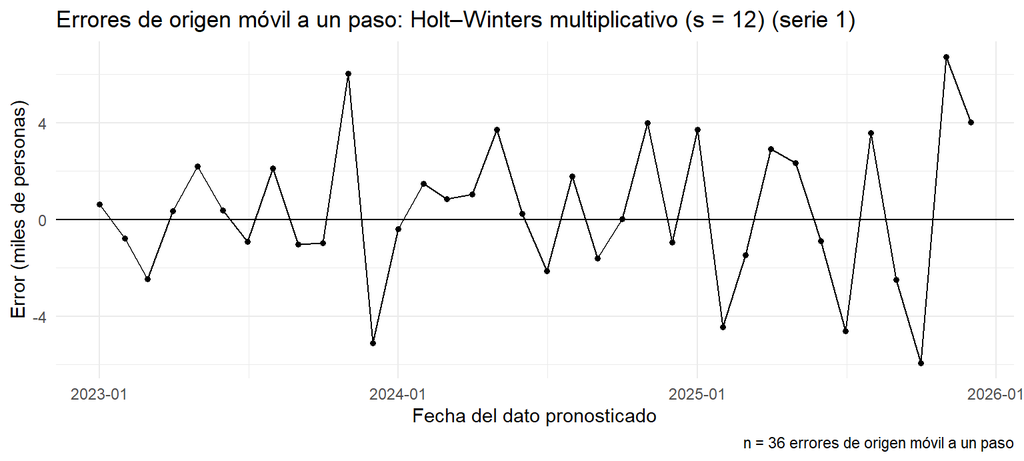

Figura 45: **?(caption)**

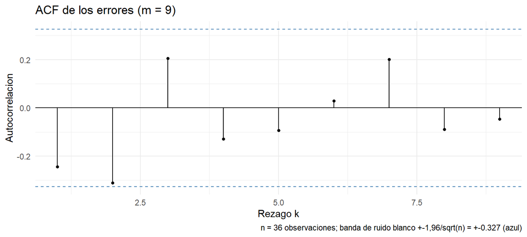

Figura 46: **?(caption)**

**Prueba t de media cero sobre los errores de origen móvil a un paso de Holt–Winters multiplicativo (s = 12)**

1. **Hipótesis.** $H_0$: $\mu = 0$. $H_1$: $\mu \neq 0$.
2. **Estadístico.** $t = \frac{\bar{x}}{s/\sqrt{n}}$. Bajo $H_0$: $t$ de Student con 35 grados de libertad.
3. **Región de rechazo al 5 %.** $|t| > 2,03$.
4. **Valor observado.** $t = 0,6601$; valor p = 0,514.
5. **Decisión.** No se rechaza H0.
6. **Lectura.** No hay evidencia de que la media de los errores de origen móvil a un paso de Holt–Winters multiplicativo (s = 12) (0,328) sea distinta de 0: no se detecta sesgo.

**Prueba de Ljung-Box sobre los errores de origen móvil a un paso de Holt–Winters multiplicativo (s = 12) (m = 9)**

1. **Hipótesis.** $H_0$: $\rho_1 = \dots = \rho_m = 0$ (no hay autocorrelación hasta el rezago $m$). $H_1$: algún $\rho_k \neq 0$ con $k \leq m$.
2. **Estadístico.** $Q = n(n+2)\sum_{k=1}^{m} \frac{r_k^2}{n-k}$. Bajo $H_0$: $\chi^2$ con 9 grados de libertad.
3. **Región de rechazo al 5 %.** $Q > 16,92$.
4. **Valor observado.** $Q = 11,48$; valor p = 0,244.
5. **Decisión.** No se rechaza H0.
6. **Lectura.** No hay evidencia de autocorrelación en los errores de origen móvil a un paso de Holt–Winters multiplicativo (s = 12) hasta el rezago 9: es compatible con ruido blanco.

**Prueba de Jarque-Bera sobre los errores de origen móvil a un paso de Holt–Winters multiplicativo (s = 12)**

1. **Hipótesis.** $H_0$: asimetría $= 0$ y curtosis $= 3$ (normalidad). $H_1$: asimetría $\neq 0$ o curtosis $\neq 3$.
2. **Estadístico.** $JB = \frac{n}{6}\left(S^2 + \frac{(K-3)^2}{4}\right)$. Bajo $H_0$: $\chi^2$ con 2 grados de libertad.
3. **Región de rechazo al 5 %.** $JB > 5,991$.
4. **Valor observado.** $JB = 0,1173$; valor p = 0,943.
5. **Decisión.** No se rechaza H0.
6. **Lectura.** No hay evidencia contra la normalidad de los errores de origen móvil a un paso de Holt–Winters multiplicativo (s = 12) ($S =$ -0,02431, $K =$ 2,725).

**Durbin–Watson.** $d =$ 2,413; la aproximación $2(1-r_1) =$ 2,488 con $r_1 =$ -0,244. Lectura: d cerca de 2: sin autocorrelación de orden 1 apreciable.

### 6.5.2 Serie 2: suavizamiento exponencial simple

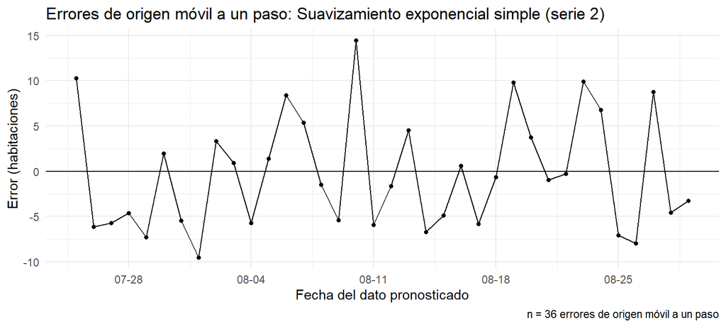

Figura 47: **?(caption)**

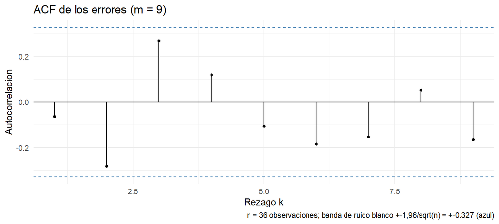

Figura 48: **?(caption)**

**Prueba t de media cero sobre los errores de origen móvil a un paso de Suavizamiento exponencial simple**

1. **Hipótesis.** $H_0$: $\mu = 0$. $H_1$: $\mu \neq 0$.
2. **Estadístico.** $t = \frac{\bar{x}}{s/\sqrt{n}}$. Bajo $H_0$: $t$ de Student con 35 grados de libertad.
3. **Región de rechazo al 5 %.** $|t| > 2,03$.
4. **Valor observado.** $t = -0,2849$; valor p = 0,777.
5. **Decisión.** No se rechaza H0.
6. **Lectura.** No hay evidencia de que la media de los errores de origen móvil a un paso de Suavizamiento exponencial simple (-0,3003) sea distinta de 0: no se detecta sesgo.

**Prueba de Ljung-Box sobre los errores de origen móvil a un paso de Suavizamiento exponencial simple (m = 9)**

1. **Hipótesis.** $H_0$: $\rho_1 = \dots = \rho_m = 0$ (no hay autocorrelación hasta el rezago $m$). $H_1$: algún $\rho_k \neq 0$ con $k \leq m$.
2. **Estadístico.** $Q = n(n+2)\sum_{k=1}^{m} \frac{r_k^2}{n-k}$. Bajo $H_0$: $\chi^2$ con 9 grados de libertad.
3. **Región de rechazo al 5 %.** $Q > 16,92$.
4. **Valor observado.** $Q = 11,62$; valor p = 0,236.
5. **Decisión.** No se rechaza H0.
6. **Lectura.** No hay evidencia de autocorrelación en los errores de origen móvil a un paso de Suavizamiento exponencial simple hasta el rezago 9: es compatible con ruido blanco.

**Prueba de Jarque-Bera sobre los errores de origen móvil a un paso de Suavizamiento exponencial simple**

1. **Hipótesis.** $H_0$: asimetría $= 0$ y curtosis $= 3$ (normalidad). $H_1$: asimetría $\neq 0$ o curtosis $\neq 3$.
2. **Estadístico.** $JB = \frac{n}{6}\left(S^2 + \frac{(K-3)^2}{4}\right)$. Bajo $H_0$: $\chi^2$ con 2 grados de libertad.
3. **Región de rechazo al 5 %.** $JB > 5,991$.
4. **Valor observado.** $JB = 2,886$; valor p = 0,236.
5. **Decisión.** No se rechaza H0.
6. **Lectura.** No hay evidencia contra la normalidad de los errores de origen móvil a un paso de Suavizamiento exponencial simple ($S =$ 0,5879, $K =$ 2,264).

**Durbin–Watson.** $d =$ 2,036; la aproximación $2(1-r_1) =$ 2,128 con $r_1 =$ -0,064. Lectura: d cerca de 2: sin autocorrelación de orden 1 apreciable.

### 6.5.3 Serie 3: tendencia lineal

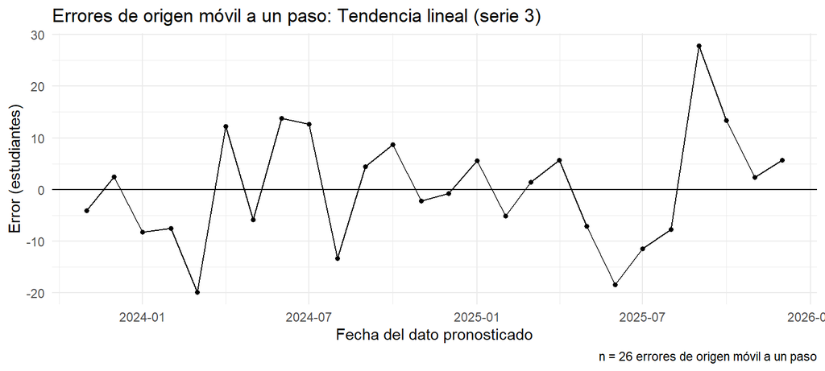

Figura 49: **?(caption)**

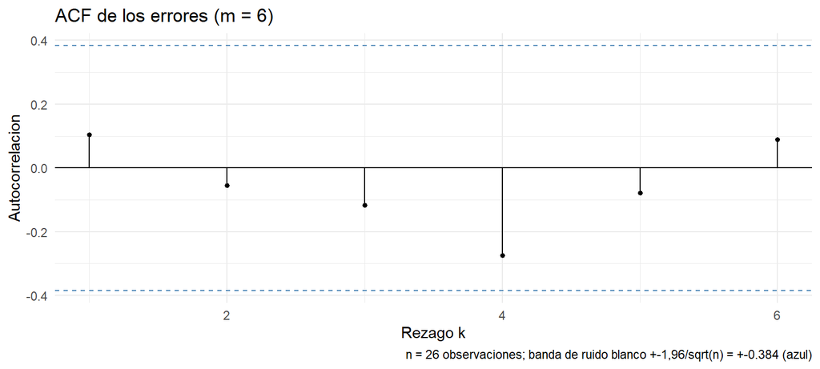

Figura 50: **?(caption)**

**Prueba t de media cero sobre los errores de origen móvil a un paso de Tendencia lineal**

1. **Hipótesis.** $H_0$: $\mu = 0$. $H_1$: $\mu \neq 0$.
2. **Estadístico.** $t = \frac{\bar{x}}{s/\sqrt{n}}$. Bajo $H_0$: $t$ de Student con 25 grados de libertad.
3. **Región de rechazo al 5 %.** $|t| > 2,06$.
4. **Valor observado.** $t = 0,07555$; valor p = 0,94.
5. **Decisión.** No se rechaza H0.
6. **Lectura.** No hay evidencia de que la media de los errores de origen móvil a un paso de Tendencia lineal (0,1631) sea distinta de 0: no se detecta sesgo.

**Prueba de Ljung-Box sobre los errores de origen móvil a un paso de Tendencia lineal (m = 6)**

1. **Hipótesis.** $H_0$: $\rho_1 = \dots = \rho_m = 0$ (no hay autocorrelación hasta el rezago $m$). $H_1$: algún $\rho_k \neq 0$ con $k \leq m$.
2. **Estadístico.** $Q = n(n+2)\sum_{k=1}^{m} \frac{r_k^2}{n-k}$. Bajo $H_0$: $\chi^2$ con 6 grados de libertad.
3. **Región de rechazo al 5 %.** $Q > 12,59$.
4. **Valor observado.** $Q = 3,825$; valor p = 0,7.
5. **Decisión.** No se rechaza H0.
6. **Lectura.** No hay evidencia de autocorrelación en los errores de origen móvil a un paso de Tendencia lineal hasta el rezago 6: es compatible con ruido blanco.

**Prueba de Jarque-Bera sobre los errores de origen móvil a un paso de Tendencia lineal**

1. **Hipótesis.** $H_0$: asimetría $= 0$ y curtosis $= 3$ (normalidad). $H_1$: asimetría $\neq 0$ o curtosis $\neq 3$.
2. **Estadístico.** $JB = \frac{n}{6}\left(S^2 + \frac{(K-3)^2}{4}\right)$. Bajo $H_0$: $\chi^2$ con 2 grados de libertad.
3. **Región de rechazo al 5 %.** $JB > 5,991$.
4. **Valor observado.** $JB = 0,4067$; valor p = 0,816.
5. **Decisión.** No se rechaza H0.
6. **Lectura.** No hay evidencia contra la normalidad de los errores de origen móvil a un paso de Tendencia lineal ($S =$ 0,3063, $K =$ 3,01).

**Durbin–Watson.** $d =$ 1,775; la aproximación $2(1-r_1) =$ 1,792 con $r_1 =$ 0,104. Lectura: d cerca de 2: sin autocorrelación de orden 1 apreciable.

**Lectura conjunta.** En las tres series ningún rezago de la ACF de los errores sale de la banda (0 rezagos fuera en total), la media de los errores no se distingue de cero y Ljung–Box no rechaza, de modo que no se detecta estructura sin aprovechar a un paso. Jarque–Bera tampoco rechaza normalidad, lo que respalda leer la banda de pronóstico de $\pm 1{,}96$ desviaciones como una regla razonable (siempre heurística). El estadístico de Durbin–Watson es 2,41 en la serie 1, 2,04 en la serie 2 y 1,78 en la serie 3, sin desvíos apreciables de 2. La advertencia que corresponde es la de potencia: con 36, 36 y 26 errores, estas pruebas solo detectarían una autocorrelación grande. Por eso, además de las pruebas, importa que la comparación con el referente se haya hecho sobre los mismos orígenes.

## 6.6 Pronóstico final

Con el método ganador reajustado sobre **toda** la serie se pronostican los $H$ períodos siguientes. Como el pronóstico responde a la pregunta de horizonte $H$, se usa el ganador de $h = H$ de cada serie. La banda es **heurística**: pronóstico $\pm 1{,}96$ veces la desviación estándar de los errores de origen móvil a cada horizonte. No es un intervalo de confianza, no tiene una cobertura garantizada y, con 25, 28 y 21 errores por horizonte, la desviación que usa está estimada con poca información.

### 6.6.1 Serie 1: Holt–Winters multiplicativo

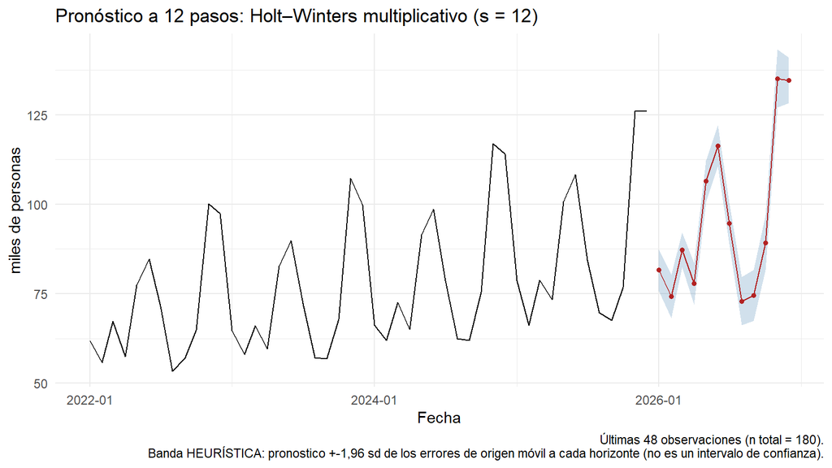

Figura 51: **?(caption)**

**?(caption)**

| h | Fecha | Pronóstico | Desv. de los errores | Banda inferior | Banda superior |
| --- | --- | --- | --- | --- | --- |
| 1 | 2026-01-01 | 81,6 | 3,0 | 75,8 | 87,5 |
| 2 | 2026-02-01 | 74,3 | 3,1 | 68,3 | 80,3 |
| 3 | 2026-03-01 | 87,3 | 2,5 | 82,4 | 92,1 |
| 4 | 2026-04-01 | 77,8 | 3,0 | 72,0 | 83,7 |
| 5 | 2026-05-01 | 106,4 | 3,0 | 100,6 | 112,2 |
| 6 | 2026-06-01 | 116,3 | 2,9 | 110,5 | 122,1 |
| 7 | 2026-07-01 | 94,7 | 2,9 | 88,9 | 100,4 |
| 8 | 2026-08-01 | 72,9 | 3,4 | 66,2 | 79,6 |
| 9 | 2026-09-01 | 74,6 | 3,6 | 67,5 | 81,6 |
| 10 | 2026-10-01 | 89,3 | 3,9 | 81,7 | 96,9 |
| 11 | 2026-11-01 | 135,1 | 4,1 | 127,0 | 143,2 |
| 12 | 2026-12-01 | 134,6 | 3,2 | 128,3 | 141,0 |

### 6.6.2 Serie 2: tendencia cuadrática

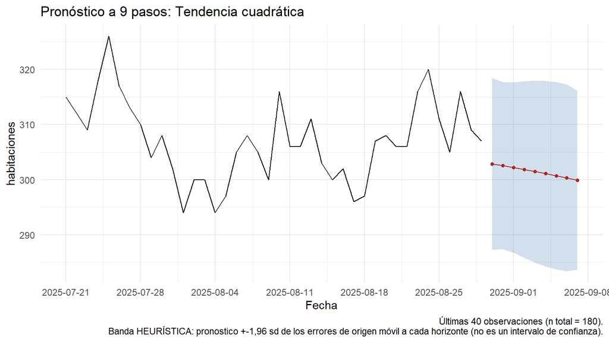

Figura 52: **?(caption)**

**?(caption)**

| h | Fecha | Día | Pronóstico | Desv. de los errores | Banda inferior | Banda superior |
| --- | --- | --- | --- | --- | --- | --- |
| 1 | 2025-08-30 | sáb | 302,9 | 7,9 | 287,3 | 318,4 |
| 2 | 2025-08-31 | dom | 302,5 | 7,7 | 287,4 | 317,7 |
| 3 | 2025-09-01 | lun | 302,2 | 7,9 | 286,7 | 317,6 |
| 4 | 2025-09-02 | mar | 301,8 | 8,2 | 285,8 | 317,9 |
| 5 | 2025-09-03 | mié | 301,5 | 8,4 | 284,9 | 318,0 |
| 6 | 2025-09-04 | jue | 301,1 | 8,6 | 284,3 | 317,9 |
| 7 | 2025-09-05 | vie | 300,7 | 8,7 | 283,7 | 317,7 |
| 8 | 2025-09-06 | sáb | 300,3 | 8,6 | 283,4 | 317,2 |
| 9 | 2025-09-07 | dom | 299,9 | 8,3 | 283,7 | 316,1 |

### 6.6.3 Serie 3: doble media móvil

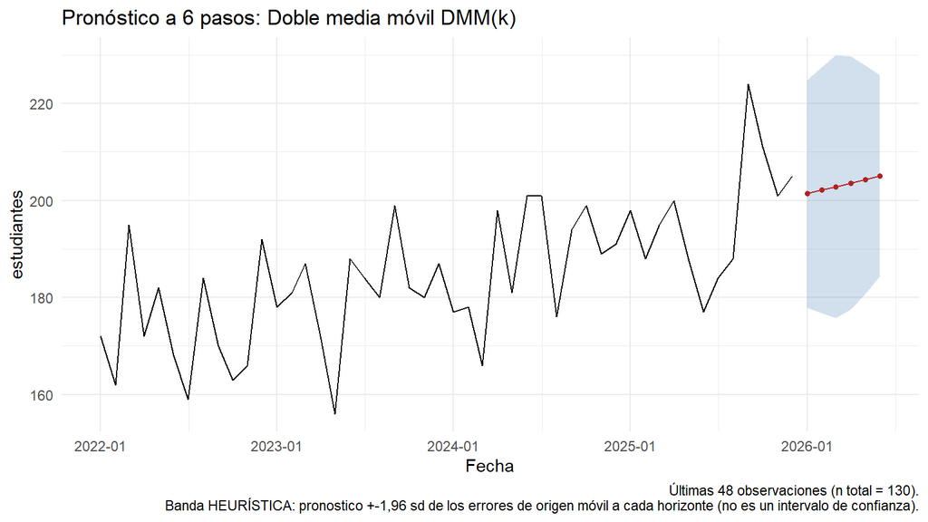

Figura 53: **?(caption)**

**?(caption)**

| h | Fecha | Pronóstico | Desv. de los errores | Banda inferior | Banda superior |
| --- | --- | --- | --- | --- | --- |
| 1 | 2026-01-01 | 201,4 | 12,0 | 177,9 | 224,8 |
| 2 | 2026-02-01 | 202,1 | 13,0 | 176,7 | 227,5 |
| 3 | 2026-03-01 | 202,9 | 13,8 | 175,8 | 229,9 |
| 4 | 2026-04-01 | 203,6 | 13,3 | 177,5 | 229,7 |
| 5 | 2026-05-01 | 204,4 | 12,0 | 180,8 | 227,9 |
| 6 | 2026-06-01 | 205,1 | 10,6 | 184,4 | 225,8 |

En la serie 1 el pronóstico repite el perfil de dos temporadas altas: el máximo de los próximos 12 meses es 135,1 mil turistas en 2026-11 y el mínimo 72,9 mil en 2026-08; la semi-amplitud de la banda va de 4,9 a 8,1 mil. En la serie 2 el pronóstico es casi plano (de 302,9 a 299,9 habitaciones) con una semi-amplitud de 15,2 a 17,0 habitaciones; que la parábola ajustada baje ligeramente no debe leerse como una predicción de caída: es la curvatura que dejó la subida inicial, y la banda es varias veces mayor que la baja. En la serie 3 el pronóstico crece de 201,4 a 205,1 estudiantes en seis meses con una semi-amplitud de 20,7 a 27,1.

# 7 Conclusión técnica

**Serie 1 (llegadas de turistas).** Tiene tendencia y estacionalidad anual multiplicativa: los índices explican 96 % de la varianza sin tendencia, la correlación entre nivel y amplitud es 0,99, y las dos temporadas altas (mayo–junio y noviembre–diciembre) llegan a índices de 1,22 y 1,37. La transformación que la vuelve plausiblemente estacionaria es $\nabla(1-B^{12})\log Y$, con varianza 0,00134 y $r_1 =$ -0,43; sobre ella Ljung–Box rechaza ruido blanco ($Q =$ 91,8) por una estructura de media móvil regular y estacional. El mejor método es Holt–Winters multiplicativo (s = 12, α = 0,5, β = 0,1, γ = 0,1): su RMSE es 2,96 mil turistas en $h = 1$ frente a 6,77 del ingenuo estacional (razón 0,44), y 4,19 en $h = 12$ frente a 7,76 (razón 0,54). En sus errores a un paso no queda estructura detectable (Ljung–Box $p =$ 0,244, ningún rezago fuera de banda), con la salvedad de que $\hat\beta$ y $\hat\gamma$ quedaron en el mínimo de la rejilla, lo que sugiere que una pendiente y un perfil aún más estables podrían ajustar mejor.

**Serie 2 (habitaciones ocupadas).** Tiene una tendencia que sube de 204 a más de 300 habitaciones y luego se estabiliza, sin estacionalidad semanal (los índices de período 7 explican solo 1,2 % de la varianza). Se vuelve plausiblemente estacionaria con una diferencia ($\nabla Y$: varianza 49,6, $r_1 =$ -0,24; la segunda diferencia sube la varianza a 123,6). En $h = 1$ el mejor método es SES con $\alpha =$ 0,72, con RMSE 6,24 frente a 6,49 del ingenuo, una ventaja de apenas 3,8 % que con 36 orígenes no es concluyente; en $h = 9$ gana la tendencia cuadrática con 8,31 frente a 12,07 (razón 0,69). Los residuos de las regresiones de tendencia de esta serie están muy autocorrelacionados ($DW$ entre 0,15 y 0,41), de modo que la ventaja de la cuadrática a nueve pasos no viene de haber capturado la dinámica; en los errores a un paso de SES no queda estructura detectable (Ljung–Box $p =$ 0,236).

**Serie 3 (estudiantes matriculados).** Es una tendencia lineal determinista más ruido blanco, sin estacionalidad (ningún período explica más de 5,4 % de la varianza). La primera diferencia sobrediferencia ($r_1 =$ -0,51, varianza 171,9, aproximadamente el doble de la de los residuos de la recta, 82,6); la transformación elegida es quitar la recta, que deja residuos compatibles con ruido blanco (Ljung–Box $p =$ 0,175). En $h = 1$ gana la tendencia lineal (RMSE 10,79 estudiantes frente a 14,17 del ingenuo, razón 0,76) y en $h = 6$ la doble media móvil con $k =$ 12 (10,35 frente a 14,55, razón 0,71), aunque los cinco primeros métodos están dentro de 9 % en $h=1$. En los errores a un paso de la recta no queda estructura detectable (Ljung–Box $p =$ 0,700, $DW =$ 1,78), con solo 26 errores.

**Comparación y por qué los ganadores cambian.** Ningún método gana en las tres series ni en los dos horizontes, y las razones se ven en las tablas. La tendencia lineal, ganadora en la serie 3, tiene un RMSE 3,8 veces el del referente en la serie 2 y 2,9 veces en la serie 1 (a un paso): sirve cuando la pendiente es estable (serie 3, residuos sin autocorrelación), no cuando la serie sube y se aplana (serie 2) ni cuando domina la estacionalidad (serie 1). Holt–Winters multiplicativo, ganador en la serie 1 con una razón de 0,44, no se aplicó donde no hay estacionalidad, y el aditivo, como contraste, queda con razones de 1,04 en la serie 2 y 0,84 en la serie 3: en ninguna supera con claridad a métodos más simples, porque estima un perfil estacional que esas series no tienen. El referente también cambia de dureza: en la serie 1 el ingenuo estacional se supera con holgura (mejora de 56 %), en la serie 2 el ingenuo es casi imbatible a un paso (mejora de 3,8 %) y en la serie 3 es un referente débil (el mejor método reduce el error 24 %). Por último, el horizonte cambia al ganador en las series 2 y 3 (SES contra tendencia cuadrática, y tendencia lineal contra doble media móvil): lo que mejor pronostica el día siguiente no es lo que mejor pronostica nueve días o seis meses adelante, y con 26 a 36 orígenes algunas de esas diferencias no se pueden distinguir del azar.

# 8 Argumentos para los interesados

## 8.1 Mapa de interesados y costo del error

El **error por exceso** es pronosticar más de lo que ocurre; el **error por defecto**, pronosticar menos. Los costos en pesos solo se calculan donde el contexto da las tarifas.

### 8.1.1 Serie 1: llegadas de turistas a Bahía Serena

**?(caption)**

| Interesado | Decisión con el pronóstico | Costo del error por exceso | Costo del error por defecto |
| --- | --- | --- | --- |
| Alcaldía | Negociar vuelos adicionales y contratar policía de turismo y salvavidas con seis meses de anticipación | Un vuelo sin ocupación suficiente se paga con recursos públicos; personal contratado sin demanda | Falta de personal: accidentes y quejas |
| Hoteleros | Planear ocupación, precios y personal por temporada | Capacidad y personal ocioso en los meses que resultan flojos | Ventas perdidas en temporada alta |
| Aerolíneas | Asignar vuelos y asientos al destino | Vuelos con asientos vacíos | Demanda que no se atiende |
| Residentes | No deciden; viven las consecuencias de la afluencia | Preparativos que no se necesitaban | Servicios y playas saturados |

El contexto no da tarifas de vuelos ni de personal, de modo que el costo no se expresa en pesos; se expresa en la unidad de la serie. El error típico del pronóstico a 12 pasos (RMSE de origen móvil) es de 4,19 mil turistas por mes, un 4,2 % del nivel (MAPE), frente a 7,76 mil de la regla de copiar el mismo mes del año anterior.

### 8.1.2 Serie 2: habitaciones ocupadas por noche

**?(caption)**

| Interesado | Decisión con el pronóstico | Costo del error por exceso | Costo del error por defecto |
| --- | --- | --- | --- |
| Gerencia del hotel | Cuántas reservas aceptar por encima de la capacidad de 340 habitaciones | Reservas rechazadas que se habrían podido atender | Cada huésped reubicado en otro hotel cuesta 450.000 COP por noche; si cada habitación de un error de 8,3 terminara en reubicación, serían 3,7 M COP por noche (cota ilustrativa) |
| Personal de limpieza | Cuántas camareras trabajan cada día (una por cada 14 habitaciones ocupadas) | Camareras programadas de más; un error de 8,3 habitaciones equivale a 0,59 camareras | Faltan camareras: habitaciones sin limpiar o sobrecarga |
| Empresas que envían huéspedes | Dónde alojar a sus empleados y visitantes | Poca disponibilidad aparente | Su gente es reubicada en otro hotel |

### 8.1.3 Serie 3: estudiantes matriculados en cursos virtuales

**?(caption)**

| Interesado | Decisión con el pronóstico | Costo del error por exceso | Costo del error por defecto |
| --- | --- | --- | --- |
| Dirección de extensión | Cuántos tutores contratar para el semestre (cada uno atiende hasta 25 estudiantes y se contrata por seis meses) | Cada tutor de más cuesta 3,2 M COP al mes, es decir 19,2 M COP en el semestre | Un grupo sin tutor genera deserción y quejas (el contexto no da tarifa) |
| Tutores | Aceptar el grupo que se les asigne | Grupos más pequeños de lo necesario | Más de 25 estudiantes por tutor |
| Estudiantes | No deciden; dependen de que haya tutor | Ninguno directo | Quedar en un grupo sin tutor: deserción |

El error típico del pronóstico a seis meses es de 10,4 estudiantes, o sea 0,41 de un tutor.

## 8.2 El argumento en cinco partes

### 8.2.1 Serie 1

**Afirmación.** En 2026 llegarán entre unos 73 y 135 mil turistas por mes, con dos temporadas altas, mayo–junio y sobre todo noviembre–diciembre, y el mes más bajo en agosto; los vuelos y el personal deben planearse para esas temporadas.

**Evidencia.** El pronóstico para los próximos 12 meses va de 72,9 mil (2026-08) a 135,1 mil (2026-11). Probado hacia atrás en 25 fechas distintas, el método se equivocó en promedio cuadrático por 4,19 mil turistas a 12 meses (4,2 % del nivel), contra 7,76 mil de la regla de repetir el mes del año anterior.

**Justificación.** Las llegadas siguen un calendario que se repite cada año y, a la vez, crecen. El método mide cuánto crece el nivel y cuánto pesa cada mes, y los actualiza con cada dato nuevo; por eso mejora la regla de copiar el año pasado, que no incorpora el crecimiento.

**Alcance.** La recomendación vale para los próximos 12 meses, siempre que el calendario de temporadas se mantenga; cambiaría ante un choque (cierre de vuelos, un evento grande) o si el perfil de las temporadas se desplaza, y conviene reajustarla con cada dato nuevo. La banda de $\pm 1{,}96$ desviaciones es una guía, no una garantía: para los meses 6 a 12, que son los que la alcaldía debe contratar con anticipación, la desviación de los errores va de 2,9 a 4,1 mil turistas.

**Objeción y respuesta.** *“Copiar el mes del año pasado es más simple de explicar y parece casi igual.”* No es casi igual: en las mismas 25 pruebas, ese atajo se equivocó 7,76 mil frente a 4,19 mil del método elegido, es decir, el atajo comete un error 85 % mayor.

### 8.2.2 Serie 2

**Afirmación.** Para la semana del lunes 1 al domingo 7 de septiembre de 2025 se esperan unas 300 a 302 habitaciones ocupadas por noche, bastante por debajo de las 340 de capacidad; con eso se programan 22 camareras por noche, y 23 si se quiere cubrir el extremo alto.

**Evidencia.** El pronóstico para esa semana va de 299,9 a 302,2 habitaciones y el extremo alto de la banda es 318,0, a 22 habitaciones de la capacidad. A nueve días, el error típico del método elegido es de 8,31 habitaciones, contra 12,07 de suponer que dentro de nueve días será igual que hoy.

**Justificación.** La ocupación subió durante los primeros meses y desde entonces se mantiene alta con oscilaciones; no hay un patrón por día de la semana que distinga, por ejemplo, el lunes del sábado. El método sigue ese nivel y su ligera curvatura.

**Alcance.** Vale para los próximos nueve días. Que el pronóstico baje levemente (de 302,9 a 299,9) no es una predicción de caída: es la curvatura que dejó la subida inicial, y la banda es varias veces mayor que esa baja. Un cambio de temporada, un evento o un contrato corporativo lo invalidaría.

**Objeción y respuesta.** *“Si decir ‘igual que hoy’ casi no pierde, ¿para qué un modelo?”* A un día, la objeción tiene razón: el método elegido mejora al “igual que hoy” apenas 3,8 %, y con 36 pruebas eso no se distingue del azar. El valor aparece a nueve días: el error baja de 12,07 a 8,31 habitaciones, 3,76 habitaciones menos, que equivalen a 0,27 camareras por noche. Es una ganancia modesta, y conviene decirla así.

### 8.2.3 Serie 3

**Afirmación.** Contratar 9 tutores cubre la matrícula esperada del semestre (hasta unos 205 estudiantes, que son 225 cupos con 9 tutores); con 10 tutores se cubre incluso el extremo alto de la banda, de 230 estudiantes.

**Evidencia.** El pronóstico crece de 201,4 a 205,1 estudiantes en seis meses; la matrícula ha crecido en promedio 0,62 estudiantes por mes, y esa pendiente es claramente distinta de cero. El error típico a seis meses es de 10,4 estudiantes (0,41 de un tutor), contra 14,5 de suponer que seguirá igual que el último mes.

**Justificación.** La matrícula crece de forma sostenida y regular, sin altibajos por mes del año: es una recta con ruido. Mientras esa recta se mantenga, el crecimiento de los próximos meses se parece al de los pasados.

**Alcance.** Vale para el próximo semestre. Cambiaría si se lanza un programa nuevo, si cambia la deserción o si el ritmo de crecimiento se modifica; los datos usados llegan hasta diciembre de 2025. La banda es heurística.

**Objeción y respuesta.** *“¿Y si la matrícula supera lo previsto y quedan estudiantes sin tutor?”* Con 9 tutores hay 225 cupos, y el extremo alto de la banda llega a 230: quedarían unos 5 estudiantes sin cupo en el peor extremo de la banda. Un décimo tutor cubriría ese extremo y cuesta 19,2 M COP en el semestre; es una decisión de la dirección entre ese costo seguro y el riesgo de un grupo pequeño sin tutor, que el pronóstico no puede resolver por sí solo.

## 8.3 La nota para los interesados

La nota de una página, sin fórmulas ni términos del curso y con un gráfico por serie, está en `informe/nota-interesados.pdf`; resume los argumentos de esta sección con las mismas cifras.